# R Notebook

```r
library(ggplot2)
library(stringr)
library(pheatmap)
library(ensembldb)
library(biomaRt)
library(ggpubr)
library(tidyverse)
library(foreach)
library(DESeq2)
library(data.table)
library(ALDEx2)
```

| SETUP |
| --- |

Load gene family data (in kegg IDs) and tidy up

```r
#gene_families <- read.csv("data/metaG-functional/genefam_combined.tsv", header =T, sep = "\t")
#gene_families2 <- gene_families %>%
  # remove X from colnames
#  rename_all(~gsub("^X", "", .)) %>%
  # remove "_Abundance.RPKs" string from colnames
#  rename_all(~str_remove(.x, "_Abundance.RPKs")) %>%
  # rename first column
#  rename_at(1, ~"GeneFamily")

#gene_families_filt1 <- gene_families2 %>%
  # for now, filter at the gene level, don't include microbe contributions
#  filter(!grepl("\\|", GeneFamily))
```

This is a lot of data…lets start at the pathway level instead.

Load abundances of pathways

```r
pathway_abundances <- read.csv("data/metaG-functional/pathabun_combined.tsv", header =T, sep = "\t")
pathway_abundances2 <- pathway_abundances %>%
  # remove X from colnames
  rename_all(~gsub("^X", "", .)) %>%
  # remove "_Abundance" string from colnames
  rename_all(~str_remove(.x, "_Abundance")) %>%
  # rename first column
  rename_at(1, ~"Pathway") %>%
  # finally, tweak pathway names for compatibility with formula
  # tried simple quotes, which produced a few different errors
  # replace spaces with underscores
  mutate(Pathway = str_replace_all(Pathway, " ", "_")) %>%
  # replace special characters with underscores
  mutate(Pathway = str_replace_all(Pathway, "[^A-Za-z0-9_|]", "_")) %>%
  # add prefix "mc_" to Pathway names. prevents error if they start with a number
  mutate(Pathway = paste0("mc_", Pathway)) %>%
  # convert Pathway column to factor
  mutate(Pathway = as.factor(Pathway))
```

Import metadata

```r
meta <- read.csv("data/metadata/meta_RNAseq.csv", row.names = 1)
# Identify missing samples
remove_from_abun <- setdiff(colnames(pathway_abundances2), meta$SampleName)
remove_from_meta <- setdiff(meta$SampleName, colnames(pathway_abundances2))
# Clean up metadata specific for this analysis
meta <- meta %>%
  # exclude controls
  dplyr::filter(!Luca_Lab_ID=="control") %>%
  dplyr::filter(!SampleID==c("GMCC1S1", "GMCC1S6", "GMCC2S3", "GMCC4S7")) %>%
  dplyr::filter(!SampleName=="4342XH") %>%
  # exclude samples absent in pathway data
  dplyr::filter(!SampleName %in% remove_from_meta) %>%
  mutate(Batch = as.character(Batch)) %>%
  mutate(urbanism2=ifelse(country=="USA", "USA_urban", urbanism)) %>%
  mutate(SampleName2 = SampleName) %>%
  column_to_rownames("SampleName2") %>%
  dplyr::mutate(flag = case_when(
    country == "Ghana" ~ "data/metaG-QC/flags/ghana.svg",
    country == "Malaysia" ~ "data/metaG-QC/flags/malaysia.svg",
    country == "Nigeria" ~ "data/metaG-QC/flags/nigeria.svg",
    country == "Rwanda" ~ "data/metaG-QC/flags/rwanda.svg",
    country == "USA" ~ "data/metaG-QC/flags/usa.svg"))
meta <- meta[order(row.names(meta)), ]
```

Now sort through this data to decide what to test.

First let’s filter for relevant pathways.

```r
pathway_abundances_filt1 <- pathway_abundances2 %>%
  # for now, filter at the pathway level, don't include microbe contributions
  dplyr::filter(!grepl("\\|", Pathway)) %>%
  # Remove unmapped and unintegrated
  dplyr::filter(!Pathway=="mc_UNMAPPED") %>%
  dplyr::filter(!Pathway=="mc_UNINTEGRATED") %>%
  dplyr::select(Pathway, meta$SampleName)
```

Remove pathways with a relative abundance of 0.01% in < 50% of rural OR < 50% of urban taxa.

```r
# Create list of the SampleIDs corresponding to different groups
urbanism_urban <- unlist(subset(meta$SampleName, meta$urbanism == "urban"))
urbanism_urban <- urbanism_urban[!(urbanism_urban %in% remove_from_meta)]
urbanism_rural <- unlist(subset(meta$SampleName, meta$urbanism == "rural"))
urbanism_rural <- urbanism_rural[!(urbanism_rural %in% remove_from_meta)]

pathway_abundances_filt1_r <- pathway_abundances_filt1 %>% tibble::column_to_rownames("Pathway")
pathway_abundances_filt1_r[] <- lapply(pathway_abundances_filt1_r, function(x) x / sum(x))

# Add columns to the counts matrix indicating the percentage of individuals with zero gene expression of each gene within a given group.
pathway_abundances_r_filt2 <- pathway_abundances_filt1_r %>%
  dplyr::mutate(perc1en5_urbanism_urban = rowSums(across(all_of(urbanism_urban))<=1/10000)/length(urbanism_urban)) %>%
  dplyr::mutate(perc1en5_urbanism_rural = rowSums(across(all_of(urbanism_rural))<=1/10000)/length(urbanism_rural)) %>%
# Keep pathways which have abundance of 1e-4 values in less than or equal to 50% of urban group samples OR [cutoff value]% of rural group samples
  subset(perc1en5_urbanism_urban <= 0.50 | perc1en5_urbanism_rural <= 0.50) %>%
  dplyr::select(-(starts_with("perc1en5"))) %>%
  as.matrix()

# Apply filtering
keepPath = rownames(pathway_abundances_r_filt2)
pathway_abundances_filt2 = pathway_abundances_filt1 %>% dplyr::filter(Pathway %in% keepPath)

paste("Total number of pathways (filt cutoff = RA > 0.01%)")
```

```
[1] "Total number of pathways (filt cutoff = RA > 0.01%)"
```

```r
paste("pre-filt: ", nrow(pathway_abundances_filt1))
```

```
[1] "pre-filt:  498"
```

```r
paste0("post-filt: ", nrow(pathway_abundances_filt2))
```

```
[1] "post-filt: 288"
```

Visualize

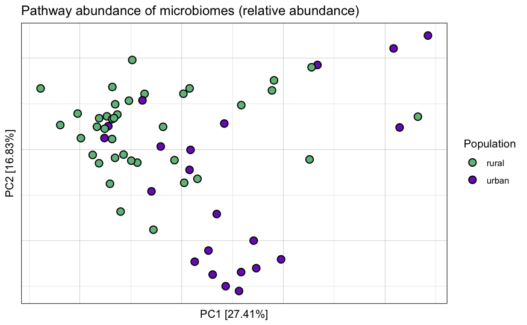

```r
pathway_abundances_filt2_r <- pathway_abundances_filt2 %>% column_to_rownames("Pathway")
pathway_abundances_filt2_r[] <- lapply(pathway_abundances_filt2_r, function(x) x / sum(x))

pca_res <- prcomp(t(pathway_abundances_filt2_r), center = TRUE, scale. = TRUE)

# Extract the principal components
principal_components <- as.data.frame(pca_res$x[, 1:2]) %>%
  rownames_to_column("SampleName") %>%
  merge(meta[,c("SampleName", "urbanism", "flag", "country")], by="SampleName")
variance_explained <- 100 * pca_res$sdev^2 / sum(pca_res$sdev^2)

ggplot(principal_components, aes(x = PC1, y = PC2)) +
  geom_point() +
  labs(x = paste("PC1 [", round(variance_explained[1], 2), "%]", sep = ""),
       y = paste("PC2 [", round(variance_explained[2], 2), "%]", sep = "")) +
  geom_point(aes(fill=urbanism), shape=21, size=3, stroke = 0.75) +
  scale_fill_manual(values=c("#6FBD8B", "#7B2BC1"), name = "Population") +
  theme_linedraw() +
  ggtitle("Pathway abundance of microbiomes (relative abundance)") +
  theme(
  axis.text = element_blank(),
  axis.ticks = element_blank()
  )
```